# Fordgo Bike Rides Exploration

## Investigation Overview

### I want to check out:

```
- Trip duration and it's relation to other variables about the user like birth year, gender ,and user_type
- The effect of date with the count of rides
```

## Dataset Overview

The data consists of information regarding 183,412 fordgo bikes trips covering the greater San Francisco Bay area in Febuary 2019, including trip start_date, trip duration, and other user realted attributes. The dataset can be found [here](https://video.udacity-data.com/topher/2020/October/5f91cf38_201902-fordgobike-tripdata/201902-fordgobike-tripdata.csv), with feature documentation available [here](https://docs.google.com/document/d/e/2PACX-1vQmkX4iOT6Rcrin42vslquX2_wQCjIa_hbwD0xmxrERPSOJYDtpNc_3wwK_p9_KpOsfA6QVyEHdxxq7/pub).

```python
# import all packages and set plots to be embedded inline
import numpy as np
import pandas as pd
import matplotlib.pyplot as plt
import seaborn as sb

%matplotlib inline

# suppress warnings from final output
import warnings
warnings.simplefilter("ignore")
```

```python
# load in the dataset into a pandas dataframe
df = pd.read_csv('201902-fordgobike-tripdata.csv')
```

> Note that the above cells have been set as "Skip"-type slides. That means that when the notebook is rendered as http slides, those cells won't show up.

## Gender distribution for users

By looking at the chart below, we can see that most fequent users are males.

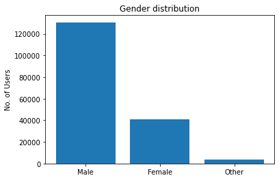

```python
plt.bar(x = df.member_gender.value_counts().keys(), height = df.member_gender.value_counts() )
plt.title('Gender distribution')
plt.ylabel('No. of Users')
plt.show()
```

## user-type distribution for users

By looking at the chart below, we can see that most users are subsribers other than Customers.

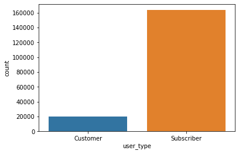

```python
sb.countplot(data = df, x = 'user_type')
```

## Duration in seconds relation to user type

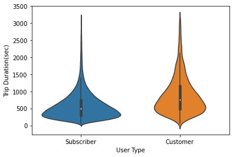

```python
df = df.query('duration_sec <= 3176')
sb.violinplot(data=df, x='user_type', y='duration_sec')
plt.xlabel('User Type');
plt.ylabel('Trip Duration(sec)')
```

> Once you're ready to finish your presentation, check your output by using nbconvert to export the notebook and set up a server for the slides. From the terminal or command line, use the following expression:

> > `jupyter nbconvert <file_name>.ipynb --to slides --post serve --template output_toggle`

> This should open a tab in your web browser where you can scroll through your presentation. Sub-slides can be accessed by pressing 'down' when viewing its parent slide. Make sure you remove all of the quote-formatted guide notes like this one before you finish your presentation!